# Risk Factor Analysis

## Outcome Variable

**Outcome Variable:** ever_wasted

## Predictor Variables

**Intervention Variable:** hdlvry

**Adjustment Set:**

- arm
- sex
- W_mage
- meducyrs
- feducyrs
- hhwealth_quart
- single
- W_nrooms
- brthmon
- W_parity
- impsan
- delta_W_mage
- delta_meducyrs
- delta_feducyrs
- delta_hhwealth_quart
- delta_single
- delta_W_nrooms
- delta_brthmon
- delta_W_parity
- delta_impsan

## Stratifying Variables

The analysis was stratified on these variable(s):

- agecat
- studyid
- country

## Data Summary

| agecat | studyid | country | hdlvry | ever_wasted | n_cell | n |
| --- | --- | --- | --- | --- | --- | --- |
| 0-24 months (no birth wast) | CMC-V-BCS-2002 | INDIA | 0 | 0 | 196 | 365 |
| 0-24 months (no birth wast) | CMC-V-BCS-2002 | INDIA | 0 | 1 | 161 | 365 |
| 0-24 months (no birth wast) | CMC-V-BCS-2002 | INDIA | 1 | 0 | 5 | 365 |
| 0-24 months (no birth wast) | CMC-V-BCS-2002 | INDIA | 1 | 1 | 3 | 365 |
| 0-24 months (no birth wast) | COHORTS | INDIA | 0 | 0 | 2513 | 4904 |
| 0-24 months (no birth wast) | COHORTS | INDIA | 0 | 1 | 517 | 4904 |
| 0-24 months (no birth wast) | COHORTS | INDIA | 1 | 0 | 1423 | 4904 |
| 0-24 months (no birth wast) | COHORTS | INDIA | 1 | 1 | 451 | 4904 |
| 0-24 months (no birth wast) | EE | PAKISTAN | 0 | 0 | 117 | 375 |
| 0-24 months (no birth wast) | EE | PAKISTAN | 0 | 1 | 135 | 375 |
| 0-24 months (no birth wast) | EE | PAKISTAN | 1 | 0 | 56 | 375 |
| 0-24 months (no birth wast) | EE | PAKISTAN | 1 | 1 | 67 | 375 |
| 0-24 months (no birth wast) | GMS-Nepal | NEPAL | 0 | 0 | 83 | 613 |
| 0-24 months (no birth wast) | GMS-Nepal | NEPAL | 0 | 1 | 65 | 613 |
| 0-24 months (no birth wast) | GMS-Nepal | NEPAL | 1 | 0 | 221 | 613 |
| 0-24 months (no birth wast) | GMS-Nepal | NEPAL | 1 | 1 | 244 | 613 |
| 0-24 months (no birth wast) | IRC | INDIA | 0 | 0 | 190 | 409 |
| 0-24 months (no birth wast) | IRC | INDIA | 0 | 1 | 211 | 409 |
| 0-24 months (no birth wast) | IRC | INDIA | 1 | 0 | 6 | 409 |
| 0-24 months (no birth wast) | IRC | INDIA | 1 | 1 | 2 | 409 |
| 0-24 months (no birth wast) | JiVitA-3 | BANGLADESH | 0 | 0 | 34 | 346 |
| 0-24 months (no birth wast) | JiVitA-3 | BANGLADESH | 0 | 1 | 7 | 346 |
| 0-24 months (no birth wast) | JiVitA-3 | BANGLADESH | 1 | 0 | 236 | 346 |
| 0-24 months (no birth wast) | JiVitA-3 | BANGLADESH | 1 | 1 | 69 | 346 |
| 0-24 months (no birth wast) | JiVitA-4 | BANGLADESH | 0 | 0 | 888 | 4480 |
| 0-24 months (no birth wast) | JiVitA-4 | BANGLADESH | 0 | 1 | 279 | 4480 |
| 0-24 months (no birth wast) | JiVitA-4 | BANGLADESH | 1 | 0 | 2398 | 4480 |
| 0-24 months (no birth wast) | JiVitA-4 | BANGLADESH | 1 | 1 | 915 | 4480 |
| 0-24 months (no birth wast) | NIH-Crypto | BANGLADESH | 0 | 0 | 513 | 754 |
| 0-24 months (no birth wast) | NIH-Crypto | BANGLADESH | 0 | 1 | 74 | 754 |

[output cut: 66 more lines]

The following strata were considered:

- agecat: 0-24 months (no birth wast), studyid: CMC-V-BCS-2002, country: INDIA
- agecat: 0-24 months (no birth wast), studyid: COHORTS, country: INDIA
- agecat: 0-24 months (no birth wast), studyid: EE, country: PAKISTAN
- agecat: 0-24 months (no birth wast), studyid: GMS-Nepal, country: NEPAL
- agecat: 0-24 months (no birth wast), studyid: IRC, country: INDIA
- agecat: 0-24 months (no birth wast), studyid: JiVitA-3, country: BANGLADESH
- agecat: 0-24 months (no birth wast), studyid: JiVitA-4, country: BANGLADESH
- agecat: 0-24 months (no birth wast), studyid: NIH-Crypto, country: BANGLADESH
- agecat: 0-24 months (no birth wast), studyid: PROVIDE, country: BANGLADESH
- agecat: 0-24 months (no birth wast), studyid: SAS-CompFeed, country: INDIA
- agecat: 0-24 months (no birth wast), studyid: SAS-FoodSuppl, country: INDIA
- agecat: 0-24 months (no birth wast), studyid: TanzaniaChild2, country: TANZANIA, UNITED REPUBLIC OF
- agecat: 0-6 months (no birth wast), studyid: CMC-V-BCS-2002, country: INDIA
- agecat: 0-6 months (no birth wast), studyid: COHORTS, country: INDIA
- agecat: 0-6 months (no birth wast), studyid: EE, country: PAKISTAN
- agecat: 0-6 months (no birth wast), studyid: GMS-Nepal, country: NEPAL
- agecat: 0-6 months (no birth wast), studyid: IRC, country: INDIA
- agecat: 0-6 months (no birth wast), studyid: JiVitA-3, country: BANGLADESH
- agecat: 0-6 months (no birth wast), studyid: JiVitA-4, country: BANGLADESH
- agecat: 0-6 months (no birth wast), studyid: NIH-Crypto, country: BANGLADESH
- agecat: 0-6 months (no birth wast), studyid: PROVIDE, country: BANGLADESH
- agecat: 0-6 months (no birth wast), studyid: SAS-CompFeed, country: INDIA
- agecat: 0-6 months (no birth wast), studyid: SAS-FoodSuppl, country: INDIA
- agecat: 0-6 months (no birth wast), studyid: TanzaniaChild2, country: TANZANIA, UNITED REPUBLIC OF

### Dropped Strata

Some strata were dropped due to rare outcomes:

- agecat: 0-24 months (no birth wast), studyid: CMC-V-BCS-2002, country: INDIA
- agecat: 0-24 months (no birth wast), studyid: IRC, country: INDIA
- agecat: 0-6 months (no birth wast), studyid: CMC-V-BCS-2002, country: INDIA
- agecat: 0-6 months (no birth wast), studyid: IRC, country: INDIA
- agecat: 0-6 months (no birth wast), studyid: SAS-FoodSuppl, country: INDIA
- agecat: 0-6 months (no birth wast), studyid: TanzaniaChild2, country: TANZANIA, UNITED REPUBLIC OF

## Methods Detail

We're interested in the causal parameters $E[Y_a]$ for all values of $a \in \mathcal{A}$. These parameters represent the mean outcome if, possibly contrary to fact, we intervened to set all units to have $A=a$. Under the randomization and positivity assumptions, these are identified by the statistical parameters $\psi_a=E_W[E_{Y|A,W}(Y|A=a,W)]$. In addition, we're interested in the mean of $Y$, $E[Y]$ under no intervention (the observed mean). We will estimate these parameters by using SuperLearner to fit the relevant likelihood factors -- $E_{Y|A,W}(Y|A=a,W)$ and $p(A=a|W)$, and then updating our likelihood fit using a joint TMLE.

For unadjusted analyses ($W=\{\}$), initial likelihoods were estimated using Lrnr_glm to estimate the simple $E(Y|A)$ and Lrnr_mean to estimate $p(A)$. For adjusted analyses, a small library containing Lrnr_glmnet, Lrnr_xgboost, and Lrnr_mean was used.

Having estimated these parameters, we will then use the delta method to estimate relative risks and attributable risks relative to a prespecified baseline level of $A$.

# Results Detail

## Results Plots

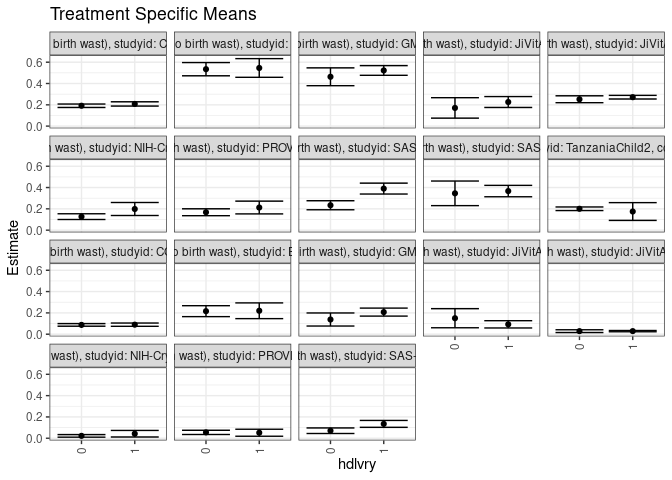

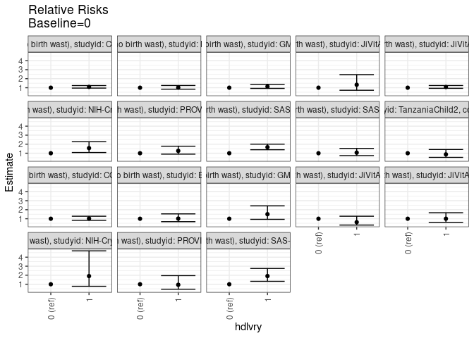

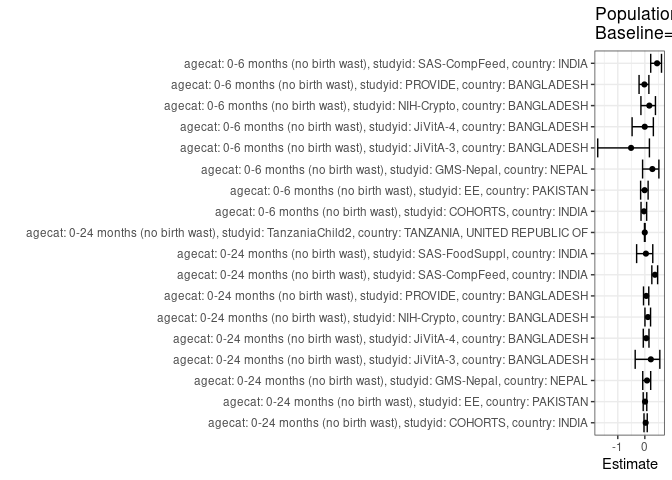

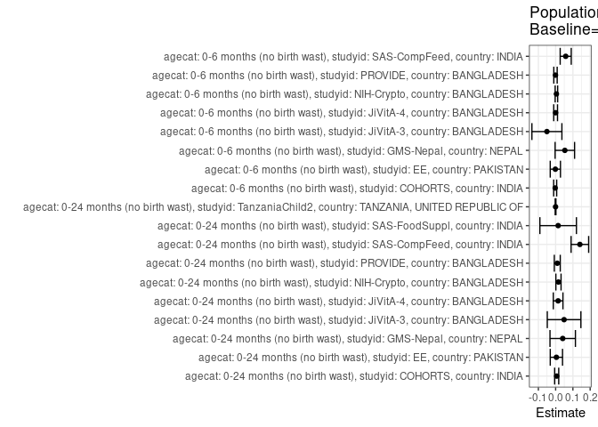

## Results Table

### Parameter: TSM

| agecat | studyid | country | intervention_level | baseline_level | estimate | ci_lower | ci_upper |
| --- | --- | --- | --- | --- | --- | --- | --- |
| 0-24 months (no birth wast) | COHORTS | INDIA | 0 | NA | 0.1912843 | 0.1751624 | 0.2074063 |
| 0-24 months (no birth wast) | COHORTS | INDIA | 1 | NA | 0.2082502 | 0.1882124 | 0.2282879 |
| 0-24 months (no birth wast) | EE | PAKISTAN | 0 | NA | 0.5342998 | 0.4723181 | 0.5962816 |
| 0-24 months (no birth wast) | EE | PAKISTAN | 1 | NA | 0.5457662 | 0.4580296 | 0.6335027 |
| 0-24 months (no birth wast) | GMS-Nepal | NEPAL | 0 | NA | 0.4631069 | 0.3794923 | 0.5467215 |
| 0-24 months (no birth wast) | GMS-Nepal | NEPAL | 1 | NA | 0.5224354 | 0.4768054 | 0.5680654 |
| 0-24 months (no birth wast) | JiVitA-3 | BANGLADESH | 0 | NA | 0.1707317 | 0.0749030 | 0.2665604 |
| 0-24 months (no birth wast) | JiVitA-3 | BANGLADESH | 1 | NA | 0.2262295 | 0.1750012 | 0.2774578 |
| 0-24 months (no birth wast) | JiVitA-4 | BANGLADESH | 0 | NA | 0.2521353 | 0.2196331 | 0.2846375 |
| 0-24 months (no birth wast) | JiVitA-4 | BANGLADESH | 1 | NA | 0.2715409 | 0.2545066 | 0.2885751 |
| 0-24 months (no birth wast) | NIH-Crypto | BANGLADESH | 0 | NA | 0.1268628 | 0.0998849 | 0.1538407 |
| 0-24 months (no birth wast) | NIH-Crypto | BANGLADESH | 1 | NA | 0.1985615 | 0.1374062 | 0.2597169 |
| 0-24 months (no birth wast) | PROVIDE | BANGLADESH | 0 | NA | 0.1680708 | 0.1357297 | 0.2004119 |
| 0-24 months (no birth wast) | PROVIDE | BANGLADESH | 1 | NA | 0.2125328 | 0.1525859 | 0.2724797 |
| 0-24 months (no birth wast) | SAS-CompFeed | INDIA | 0 | NA | 0.2337761 | 0.1914423 | 0.2761099 |
| 0-24 months (no birth wast) | SAS-CompFeed | INDIA | 1 | NA | 0.3901391 | 0.3388881 | 0.4413901 |
| 0-24 months (no birth wast) | SAS-FoodSuppl | INDIA | 0 | NA | 0.3456058 | 0.2302159 | 0.4609956 |
| 0-24 months (no birth wast) | SAS-FoodSuppl | INDIA | 1 | NA | 0.3669269 | 0.3133322 | 0.4205215 |
| 0-24 months (no birth wast) | TanzaniaChild2 | TANZANIA, UNITED REPUBLIC OF | 0 | NA | 0.2007201 | 0.1839373 | 0.2175028 |
| 0-24 months (no birth wast) | TanzaniaChild2 | TANZANIA, UNITED REPUBLIC OF | 1 | NA | 0.1750000 | 0.0916918 | 0.2583082 |
| 0-6 months (no birth wast) | COHORTS | INDIA | 0 | NA | 0.0872750 | 0.0751099 | 0.0994401 |
| 0-6 months (no birth wast) | COHORTS | INDIA | 1 | NA | 0.0894812 | 0.0742543 | 0.1047082 |
| 0-6 months (no birth wast) | EE | PAKISTAN | 0 | NA | 0.2161277 | 0.1648012 | 0.2674543 |
| 0-6 months (no birth wast) | EE | PAKISTAN | 1 | NA | 0.2201175 | 0.1462891 | 0.2939459 |
| 0-6 months (no birth wast) | GMS-Nepal | NEPAL | 0 | NA | 0.1379629 | 0.0767750 | 0.1991509 |
| 0-6 months (no birth wast) | GMS-Nepal | NEPAL | 1 | NA | 0.2074309 | 0.1699308 | 0.2449309 |
| 0-6 months (no birth wast) | JiVitA-3 | BANGLADESH | 0 | NA | 0.1500000 | 0.0603230 | 0.2396770 |
| 0-6 months (no birth wast) | JiVitA-3 | BANGLADESH | 1 | NA | 0.0927152 | 0.0586870 | 0.1267434 |
| 0-6 months (no birth wast) | JiVitA-4 | BANGLADESH | 0 | NA | 0.0287507 | 0.0157085 | 0.0417929 |
| 0-6 months (no birth wast) | JiVitA-4 | BANGLADESH | 1 | NA | 0.0288243 | 0.0229261 | 0.0347225 |
| 0-6 months (no birth wast) | NIH-Crypto | BANGLADESH | 0 | NA | 0.0222603 | 0.0102871 | 0.0342334 |
| 0-6 months (no birth wast) | NIH-Crypto | BANGLADESH | 1 | NA | 0.0424242 | 0.0116498 | 0.0731987 |
| 0-6 months (no birth wast) | PROVIDE | BANGLADESH | 0 | NA | 0.0550098 | 0.0351881 | 0.0748315 |
| 0-6 months (no birth wast) | PROVIDE | BANGLADESH | 1 | NA | 0.0517241 | 0.0187931 | 0.0846552 |
| 0-6 months (no birth wast) | SAS-CompFeed | INDIA | 0 | NA | 0.0706315 | 0.0446041 | 0.0966589 |
| 0-6 months (no birth wast) | SAS-CompFeed | INDIA | 1 | NA | 0.1348622 | 0.1024239 | 0.1673005 |

### Parameter: E(Y)

| agecat | studyid | country | intervention_level | baseline_level | estimate | ci_lower | ci_upper |
| --- | --- | --- | --- | --- | --- | --- | --- |
| 0-24 months (no birth wast) | COHORTS | INDIA | NA | NA | 0.1973899 | 0.1862487 | 0.2085311 |
| 0-24 months (no birth wast) | EE | PAKISTAN | NA | NA | 0.5386667 | 0.4881448 | 0.5891886 |
| 0-24 months (no birth wast) | GMS-Nepal | NEPAL | NA | NA | 0.5040783 | 0.4644662 | 0.5436904 |
| 0-24 months (no birth wast) | JiVitA-3 | BANGLADESH | NA | NA | 0.2196532 | 0.1732957 | 0.2660107 |
| 0-24 months (no birth wast) | JiVitA-4 | BANGLADESH | NA | NA | 0.2665179 | 0.2514258 | 0.2816100 |
| 0-24 months (no birth wast) | NIH-Crypto | BANGLADESH | NA | NA | 0.1432361 | 0.1182149 | 0.1682572 |
| 0-24 months (no birth wast) | PROVIDE | BANGLADESH | NA | NA | 0.1775837 | 0.1489858 | 0.2061816 |
| 0-24 months (no birth wast) | SAS-CompFeed | INDIA | NA | NA | 0.3741830 | 0.3195305 | 0.4288355 |
| 0-24 months (no birth wast) | SAS-FoodSuppl | INDIA | NA | NA | 0.3602015 | 0.3129196 | 0.4074834 |
| 0-24 months (no birth wast) | TanzaniaChild2 | TANZANIA, UNITED REPUBLIC OF | NA | NA | 0.2002653 | 0.1837694 | 0.2167611 |
| 0-6 months (no birth wast) | COHORTS | INDIA | NA | NA | 0.0846222 | 0.0765129 | 0.0927314 |
| 0-6 months (no birth wast) | EE | PAKISTAN | NA | NA | 0.2144772 | 0.1727666 | 0.2561878 |
| 0-6 months (no birth wast) | GMS-Nepal | NEPAL | NA | NA | 0.1912752 | 0.1596728 | 0.2228775 |
| 0-6 months (no birth wast) | JiVitA-3 | BANGLADESH | NA | NA | 0.0994152 | 0.0685873 | 0.1302431 |
| 0-6 months (no birth wast) | JiVitA-4 | BANGLADESH | NA | NA | 0.0286500 | 0.0232922 | 0.0340079 |
| 0-6 months (no birth wast) | NIH-Crypto | BANGLADESH | NA | NA | 0.0267023 | 0.0151493 | 0.0382553 |
| 0-6 months (no birth wast) | PROVIDE | BANGLADESH | NA | NA | 0.0541728 | 0.0371844 | 0.0711612 |
| 0-6 months (no birth wast) | SAS-CompFeed | INDIA | NA | NA | 0.1289517 | 0.0982960 | 0.1596075 |

### Parameter: RR

| agecat | studyid | country | intervention_level | baseline_level | estimate | ci_lower | ci_upper |
| --- | --- | --- | --- | --- | --- | --- | --- |
| 0-24 months (no birth wast) | COHORTS | INDIA | 0 | 0 | 1.0000000 | 1.0000000 | 1.000000 |
| 0-24 months (no birth wast) | COHORTS | INDIA | 1 | 0 | 1.0886943 | 0.9585364 | 1.236526 |
| 0-24 months (no birth wast) | EE | PAKISTAN | 0 | 0 | 1.0000000 | 1.0000000 | 1.000000 |
| 0-24 months (no birth wast) | EE | PAKISTAN | 1 | 0 | 1.0214604 | 0.8379937 | 1.245095 |
| 0-24 months (no birth wast) | GMS-Nepal | NEPAL | 0 | 0 | 1.0000000 | 1.0000000 | 1.000000 |
| 0-24 months (no birth wast) | GMS-Nepal | NEPAL | 1 | 0 | 1.1281097 | 0.9229732 | 1.378839 |
| 0-24 months (no birth wast) | JiVitA-3 | BANGLADESH | 0 | 0 | 1.0000000 | 1.0000000 | 1.000000 |
| 0-24 months (no birth wast) | JiVitA-3 | BANGLADESH | 1 | 0 | 1.3250585 | 0.7169637 | 2.448911 |
| 0-24 months (no birth wast) | JiVitA-4 | BANGLADESH | 0 | 0 | 1.0000000 | 1.0000000 | 1.000000 |
| 0-24 months (no birth wast) | JiVitA-4 | BANGLADESH | 1 | 0 | 1.0769650 | 0.9333674 | 1.242655 |
| 0-24 months (no birth wast) | NIH-Crypto | BANGLADESH | 0 | 0 | 1.0000000 | 1.0000000 | 1.000000 |
| 0-24 months (no birth wast) | NIH-Crypto | BANGLADESH | 1 | 0 | 1.5651674 | 1.0764283 | 2.275813 |
| 0-24 months (no birth wast) | PROVIDE | BANGLADESH | 0 | 0 | 1.0000000 | 1.0000000 | 1.000000 |
| 0-24 months (no birth wast) | PROVIDE | BANGLADESH | 1 | 0 | 1.2645438 | 0.8990985 | 1.778527 |
| 0-24 months (no birth wast) | SAS-CompFeed | INDIA | 0 | 0 | 1.0000000 | 1.0000000 | 1.000000 |
| 0-24 months (no birth wast) | SAS-CompFeed | INDIA | 1 | 0 | 1.6688580 | 1.3878128 | 2.006817 |
| 0-24 months (no birth wast) | SAS-FoodSuppl | INDIA | 0 | 0 | 1.0000000 | 1.0000000 | 1.000000 |
| 0-24 months (no birth wast) | SAS-FoodSuppl | INDIA | 1 | 0 | 1.0616921 | 0.7369422 | 1.529550 |
| 0-24 months (no birth wast) | TanzaniaChild2 | TANZANIA, UNITED REPUBLIC OF | 0 | 0 | 1.0000000 | 1.0000000 | 1.000000 |
| 0-24 months (no birth wast) | TanzaniaChild2 | TANZANIA, UNITED REPUBLIC OF | 1 | 0 | 0.8718610 | 0.5376976 | 1.413697 |
| 0-6 months (no birth wast) | COHORTS | INDIA | 0 | 0 | 1.0000000 | 1.0000000 | 1.000000 |
| 0-6 months (no birth wast) | COHORTS | INDIA | 1 | 0 | 1.0252791 | 0.8227715 | 1.277630 |
| 0-6 months (no birth wast) | EE | PAKISTAN | 0 | 0 | 1.0000000 | 1.0000000 | 1.000000 |
| 0-6 months (no birth wast) | EE | PAKISTAN | 1 | 0 | 1.0184602 | 0.6746637 | 1.537449 |
| 0-6 months (no birth wast) | GMS-Nepal | NEPAL | 0 | 0 | 1.0000000 | 1.0000000 | 1.000000 |
| 0-6 months (no birth wast) | GMS-Nepal | NEPAL | 1 | 0 | 1.5035263 | 0.9310190 | 2.428083 |
| 0-6 months (no birth wast) | JiVitA-3 | BANGLADESH | 0 | 0 | 1.0000000 | 1.0000000 | 1.000000 |
| 0-6 months (no birth wast) | JiVitA-3 | BANGLADESH | 1 | 0 | 0.6181015 | 0.2989442 | 1.277996 |
| 0-6 months (no birth wast) | JiVitA-4 | BANGLADESH | 0 | 0 | 1.0000000 | 1.0000000 | 1.000000 |
| 0-6 months (no birth wast) | JiVitA-4 | BANGLADESH | 1 | 0 | 1.0025599 | 0.6045911 | 1.662490 |
| 0-6 months (no birth wast) | NIH-Crypto | BANGLADESH | 0 | 0 | 1.0000000 | 1.0000000 | 1.000000 |
| 0-6 months (no birth wast) | NIH-Crypto | BANGLADESH | 1 | 0 | 1.9058275 | 0.7724891 | 4.701916 |
| 0-6 months (no birth wast) | PROVIDE | BANGLADESH | 0 | 0 | 1.0000000 | 1.0000000 | 1.000000 |
| 0-6 months (no birth wast) | PROVIDE | BANGLADESH | 1 | 0 | 0.9402709 | 0.4524178 | 1.954188 |
| 0-6 months (no birth wast) | SAS-CompFeed | INDIA | 0 | 0 | 1.0000000 | 1.0000000 | 1.000000 |
| 0-6 months (no birth wast) | SAS-CompFeed | INDIA | 1 | 0 | 1.9093779 | 1.3249110 | 2.751675 |

### Parameter: PAR

| agecat | studyid | country | intervention_level | baseline_level | estimate | ci_lower | ci_upper |
| --- | --- | --- | --- | --- | --- | --- | --- |
| 0-24 months (no birth wast) | COHORTS | INDIA | 0 | NA | 0.0061056 | -0.0057012 | 0.0179123 |
| 0-24 months (no birth wast) | EE | PAKISTAN | 0 | NA | 0.0043668 | -0.0311749 | 0.0399086 |
| 0-24 months (no birth wast) | GMS-Nepal | NEPAL | 0 | NA | 0.0409714 | -0.0326519 | 0.1145946 |
| 0-24 months (no birth wast) | JiVitA-3 | BANGLADESH | 0 | NA | 0.0489215 | -0.0484409 | 0.1462839 |
| 0-24 months (no birth wast) | JiVitA-4 | BANGLADESH | 0 | NA | 0.0143826 | -0.0135373 | 0.0423025 |
| 0-24 months (no birth wast) | NIH-Crypto | BANGLADESH | 0 | NA | 0.0163733 | 0.0013447 | 0.0314019 |
| 0-24 months (no birth wast) | PROVIDE | BANGLADESH | 0 | NA | 0.0095129 | -0.0077360 | 0.0267619 |
| 0-24 months (no birth wast) | SAS-CompFeed | INDIA | 0 | NA | 0.1404069 | 0.0895219 | 0.1912919 |
| 0-24 months (no birth wast) | SAS-FoodSuppl | INDIA | 0 | NA | 0.0145957 | -0.0912267 | 0.1204182 |
| 0-24 months (no birth wast) | TanzaniaChild2 | TANZANIA, UNITED REPUBLIC OF | 0 | NA | -0.0004548 | -0.0025840 | 0.0016743 |
| 0-6 months (no birth wast) | COHORTS | INDIA | 0 | NA | -0.0026528 | -0.0114223 | 0.0061167 |
| 0-6 months (no birth wast) | EE | PAKISTAN | 0 | NA | -0.0016505 | -0.0312649 | 0.0279639 |
| 0-6 months (no birth wast) | GMS-Nepal | NEPAL | 0 | NA | 0.0533122 | -0.0031215 | 0.1097460 |
| 0-6 months (no birth wast) | JiVitA-3 | BANGLADESH | 0 | NA | -0.0505848 | -0.1374669 | 0.0362973 |
| 0-6 months (no birth wast) | JiVitA-4 | BANGLADESH | 0 | NA | -0.0001007 | -0.0110970 | 0.0108956 |
| 0-6 months (no birth wast) | NIH-Crypto | BANGLADESH | 0 | NA | 0.0044420 | -0.0028570 | 0.0117410 |
| 0-6 months (no birth wast) | PROVIDE | BANGLADESH | 0 | NA | -0.0008371 | -0.0106296 | 0.0089555 |
| 0-6 months (no birth wast) | SAS-CompFeed | INDIA | 0 | NA | 0.0583203 | 0.0263022 | 0.0903383 |

### Parameter: PAF

| agecat | studyid | country | intervention_level | baseline_level | estimate | ci_lower | ci_upper |
| --- | --- | --- | --- | --- | --- | --- | --- |
| 0-24 months (no birth wast) | COHORTS | INDIA | 0 | NA | 0.0309315 | -0.0307691 | 0.0889387 |
| 0-24 months (no birth wast) | EE | PAKISTAN | 0 | NA | 0.0081067 | -0.0601288 | 0.0719503 |
| 0-24 months (no birth wast) | GMS-Nepal | NEPAL | 0 | NA | 0.0812798 | -0.0771917 | 0.2164376 |
| 0-24 months (no birth wast) | JiVitA-3 | BANGLADESH | 0 | NA | 0.2227214 | -0.3565950 | 0.5546483 |
| 0-24 months (no birth wast) | JiVitA-4 | BANGLADESH | 0 | NA | 0.0539648 | -0.0570619 | 0.1533301 |
| 0-24 months (no birth wast) | NIH-Crypto | BANGLADESH | 0 | NA | 0.1143096 | 0.0045001 | 0.2120065 |
| 0-24 months (no birth wast) | PROVIDE | BANGLADESH | 0 | NA | 0.0535687 | -0.0484734 | 0.1456797 |
| 0-24 months (no birth wast) | SAS-CompFeed | INDIA | 0 | NA | 0.3752360 | 0.2590454 | 0.4732065 |
| 0-24 months (no birth wast) | SAS-FoodSuppl | INDIA | 0 | NA | 0.0405211 | -0.3031878 | 0.2935785 |
| 0-24 months (no birth wast) | TanzaniaChild2 | TANZANIA, UNITED REPUBLIC OF | 0 | NA | -0.0022711 | -0.0129474 | 0.0082927 |
| 0-6 months (no birth wast) | COHORTS | INDIA | 0 | NA | -0.0313489 | -0.1402895 | 0.0671838 |
| 0-6 months (no birth wast) | EE | PAKISTAN | 0 | NA | -0.0076955 | -0.1556768 | 0.1213372 |
| 0-6 months (no birth wast) | GMS-Nepal | NEPAL | 0 | NA | 0.2787202 | -0.0826671 | 0.5194787 |
| 0-6 months (no birth wast) | JiVitA-3 | BANGLADESH | 0 | NA | -0.5088235 | -1.7418198 | 0.1696944 |
| 0-6 months (no birth wast) | JiVitA-4 | BANGLADESH | 0 | NA | -0.0035146 | -0.4708886 | 0.3153516 |
| 0-6 months (no birth wast) | NIH-Crypto | BANGLADESH | 0 | NA | 0.1663527 | -0.1444437 | 0.3927462 |
| 0-6 months (no birth wast) | PROVIDE | BANGLADESH | 0 | NA | -0.0154516 | -0.2132370 | 0.1500903 |
| 0-6 months (no birth wast) | SAS-CompFeed | INDIA | 0 | NA | 0.4522642 | 0.2174265 | 0.6166309 |